# Bayesian kernel machine regression for heteroscedastic health outcome data: Example analysis

```r
# Load packages
library(nimble) # For model fitting
library(coda) # For model diagnostics
library(ggplot2) # For residual plots
library(gridExtra) # For plot grids
library(ggplot2)
library(ggtext)

# Source helper functions
source("makeK.R") # Function to generate kernel matrix
source("SimHData.R") # Function to generate heteroscedastic data
source("checkResidualVar.R") # Function to examine residual patterns
source("helper_createPlots.R") # Helper functions for plotting
source("createPlots.R") # Function to visualize h and predictions


# Reading in saved objects to make compilation faster
samples_bkmr <- readRDS("saved_objects/samples_bkmr.rds")
samples_hbkmr <- readRDS("saved_objects/samples_hbkmr.rds")

overall_hbkmr <- readRDS("saved_objects/hbkmr_overall.rds")
overall_bkmr <- readRDS("saved_objects/bkmr_overall.rds")

pred_hbkmr <- readRDS("saved_objects/hbkmr_prediction.rds")
pred_bkmr <- readRDS("saved_objects/bkmr_prediction.rds")
```

# Example Data Generation using `SimHData`

For demonstration purposes, we generate a dataset with 200 observations and a five-component mixture exhibiting a realistic correlation structure (Bobb et al. 2018). The functional form of the $h$ function specified by `hfun = 3` is

$$f(z, \text{ind}) = 4 \cdot \frac{1}{1 + \exp\left( -\frac{1}{0.3} \times
\frac{1}{4} \left( z_{\text{ind}[1]} + z_{\text{ind}[2]} + \frac{1}{2}
z_{\text{ind}[1]} z_{\text{ind}[2]} \right) \right)}$$

This is a nonlinear, non-additive function of $z_1$ and $z_2$ that also includes an interaction term between the two mixture components. One covariate is generated from a Gaussian distribution with a corresponding regression coefficient set to 2. The residual variance is simulated as a function of the third metal exposure, with the strength and direction of this relationship controlled by the `var_mult` parameter.

```r
# Seed for reproducibility
set.seed(1218)

sim_data <- SimHData(
  n = 200, M = 5, beta.true = 2, hfun = 3,
  Zgen = "realistic", ind = 1:2,
  family = "gaussian", var_metal = 3, var_mult = 1.2
)

y <- sim_data$y
X <- sim_data$X
Z <- sim_data$Z
W <- as.matrix(rep(1, length(y)))
```

The resulting relationship between the residual variance (`sigsq.true`) and the mixture components can be visualized using a scatterplot matrix. Although we specified variance to be a function of the third mixture component, a relationship between the residual variance and the remaining mixture components is induced through the realistic correlation structure we specified among the mixture components.

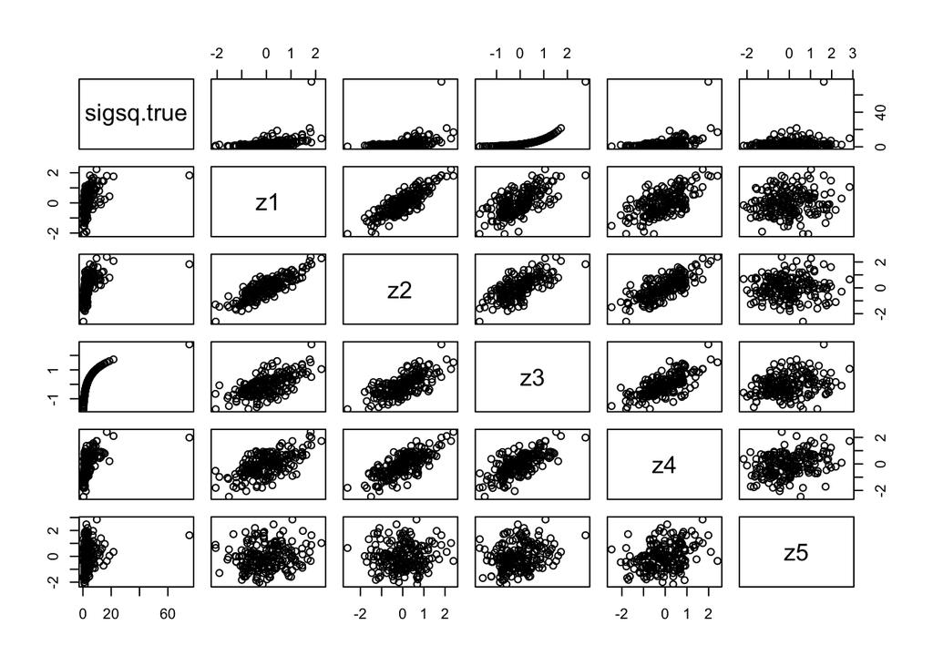

```r
plot_data <- cbind(sigsq.true = sim_data$sigsq.true, sim_data$Z)

pairs(plot_data)
```

# Fitting a BKMR Model

In the context of our NIMBLE implementation of the HBKMR model, fitting a BKMR model corresponds to specifying an intercept-only variance model. That is, the design matrix $\boldsymbol{W}$ for the variance model is an $N \times 1$ vector of ones. To that end, we fit a BKMR model to the previously simulated dataset under the model specification described in Section 3.1 of the manuscript.

```r
bkmr_code <- nimbleCode({
  sqrt_tau ~ dunif(0, 100)
  tau <- pow(sqrt_tau, 2)

  if (P <= 1) {
    beta ~ dnorm(mean = 0, var = 1e3)
  } else {
    for (p in 1:P) {
      beta[p] ~ dnorm(mean = 0, var = 1e3)
    }
  }

  for (m in 1:M) {
    inv_r[m] ~ dunif(min = 0, max = 100)
    r[m] <- 1 / inv_r[m]
  }

  if (Q <= 1) {
    gamma ~ dnorm(mean = 0, var = 1e3)
  } else {
    for (q in 1:Q) {
      gamma[q] ~ dnorm(mean = 0, var = 1e3)
    }
  }

  for (i in 1:N) {
    if (Q <= 1) {
      sigma2[i] <- exp(gamma * W[i, 1])
    } else {
      sigma2[i] <- exp(inprod(gamma[1:Q], W[i, 1:Q]))
    }
  }

  K[1:N, 1:N] <- makeK(Z = Z[1:N, 1:M], r = r[1:M], N = N, M = M)
  covar[1:N, 1:N] <- (K[1:N, 1:N] * tau) + diag(sigma2[1:N])
  chol_covar[1:N, 1:N] <- chol(covar[1:N, 1:N])

  for (i in 1:N) {
    if (P <= 1) {
      linpred[i] <- beta * X[i, 1]
    } else {
      linpred[i] <- inprod(beta[1:P], X[i, 1:P])
    }
  }
  y[1:N] ~ dmnorm(linpred[1:N], cholesky = chol_covar[1:N, 1:N], prec_param = 0)
})

N <- length(y)
M <- ncol(Z)
P <- ncol(X)
Q <- ncol(as.matrix(W))

# We specify initial values as the MLE estimates or other reasonable starting values.

lmfit0 <- lm(y ~ X + Z)
coefX <- coef(lmfit0)[grep("X", names(coef(lmfit0)))]
beta <- as.vector(unname(ifelse(is.na(coefX), 0, coefX)))
sqrt_tau <- sqrt(0.5)
inv_r <- 1 / rep(0.1, ncol(Z))
gamma <- c(log(summary(lmfit0)$sigma^2))

bkmr_model <- nimbleModel(
  code = bkmr_code,
  data = list(y = y, X = X, Z = Z, W = W),
  constants = list(N = N, M = M, P = P, Q = Q),
  inits = list(beta = beta, sqrt_tau = sqrt_tau, inv_r = inv_r, gamma = gamma)
)

# Configure MCMC
bkmr_mcmc_conf <- configureMCMC(bkmr_model, monitors = c("beta", "tau", "gamma", "r", "sigma2"), enableWAIC = TRUE)
bkmr_mcmc <- buildMCMC(bkmr_mcmc_conf)

# Compile model and MCMC
compiled_bkmr_model <- compileNimble(bkmr_model)
compiled_bkmr_mcmc <- compileNimble(bkmr_mcmc)

samples_bkmr <- runMCMC(compiled_bkmr_mcmc, niter = 1e5, nburnin = 2e4, nchains = 1, WAIC = TRUE, setSeed = 1218)

saveRDS(samples_bkmr, "saved_objects/samples_bkmr.rds")
```

## Diagnostics

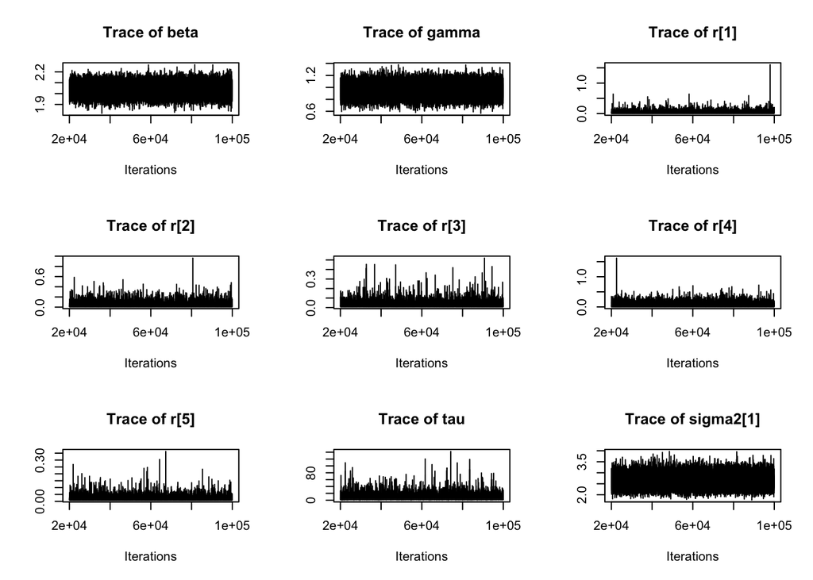

```r
pars <- c("beta", "gamma", paste0("r[", 1:5, "]"), "tau", "sigma2[1]")
available_pars <- pars[pars %in% colnames(samples_bkmr$samples)]
samples_subset <- samples_bkmr$samples[, available_pars, drop = FALSE]

coda_obj <- mcmc(samples_subset, start = 20001, end = 1e5)

par(mfrow = c(3, 3))
traceplot(coda_obj)
```

```r
par(mfrow = c(1, 1))

effectiveSize(coda_obj)
```

```
##      beta     gamma      r[1]      r[2]      r[3]      r[4]      r[5]       tau
## 18109.426 17162.756 16613.776 14079.283 17071.786 12214.117 15826.075  6832.192
## sigma2[1]
## 17095.045
```

The effective sample sizes (ESS) are generally high, with $\tau$ having the smallest ESS. The trace plots also appear satisfactory and do not indicate any pathological MCMC behaviors. We can proceed to assess the homoscedasticity assumption.

## Assessing Homoscedasticity Using the `checkResidualVar` Function

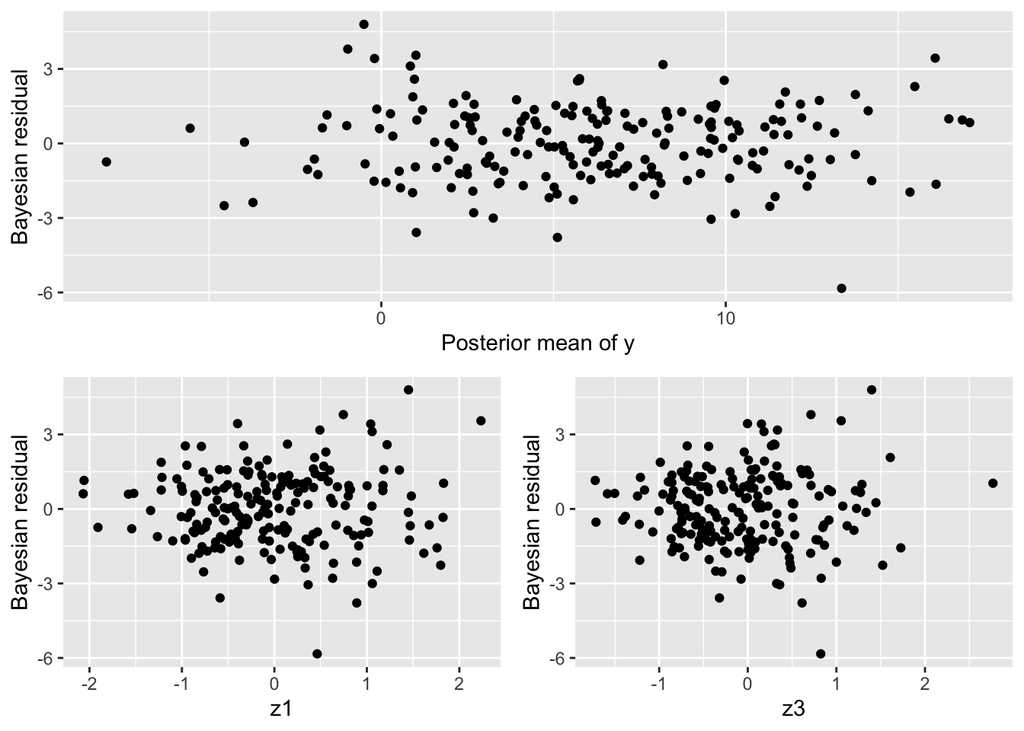

```r
colnames(X) <- "x1"

residual_plots <- checkResidualVar(
  fit = samples_bkmr, y = y, X = X, Z = Z,
  method = "exact", Z_component = 1:ncol(Z),
  X_component = 1:ncol(X), return_residuals = T,
  residuals = "bkmr", sel = NULL, categorical_X = NULL
)
```

# Fitting an HBKMR Model

Examination of the residual plots reveals a clear fanning pattern with respect to the first and third mixture components. The pattern observed for the third component is expected, as the data-generating process specified a heteroscedastic error structure dependent on this exposure in the `SimHData` function. The fanning observed with respect to the first component is attributable to its correlation with the third exposure. In response, we fit an HBKMR model that includes $z_3$ in the $\boldsymbol{W}$ matrix, which now has dimension $N \times 2$.

```r
y <- sim_data$y
X <- sim_data$X
Z <- sim_data$Z
W <- as.matrix(cbind(rep(1, length(y)), Z[,3]))
```

```r
hbkmr_code <- nimbleCode({
  sqrt_tau ~ dunif(0, 100)
  tau <- pow(sqrt_tau, 2)

  if (P <= 1) {
    beta ~ dnorm(mean = 0, var = 1e3)
  } else {
    for (p in 1:P) {
      beta[p] ~ dnorm(mean = 0, var = 1e3)
    }
  }

  for (m in 1:M) {
    inv_r[m] ~ dunif(min = 0, max = 100)
    r[m] <- 1 / inv_r[m]
  }

  if (Q <= 1) {
    gamma ~ dnorm(mean = 0, var = 1e3)
  } else {
    for (q in 1:Q) {
      gamma[q] ~ dnorm(mean = 0, var = 1e3)
    }
  }

  for (i in 1:N) {
    if (Q <= 1) {
      sigma2[i] <- exp(gamma * W[i, 1])
    } else {
      sigma2[i] <- exp(inprod(gamma[1:Q], W[i, 1:Q]))
    }
  }

  K[1:N, 1:N] <- makeK(Z = Z[1:N, 1:M], r = r[1:M], N = N, M = M)
  covar[1:N, 1:N] <- (K[1:N, 1:N] * tau) + diag(sigma2[1:N])
  chol_covar[1:N, 1:N] <- chol(covar[1:N, 1:N])

  for (i in 1:N) {
    if (P <= 1) {
      linpred[i] <- beta * X[i, 1]
    } else {
      linpred[i] <- inprod(beta[1:P], X[i, 1:P])
    }
  }
  y[1:N] ~ dmnorm(linpred[1:N], cholesky = chol_covar[1:N, 1:N], prec_param = 0)
})

N <- length(y)
M <- ncol(Z)
P <- ncol(X)
Q <- ncol(as.matrix(W))

# We specify initial values as the MLE estimates or other reasonable starting values.

lmfit0 <- lm(y ~ X + Z)
coefX <- coef(lmfit0)[grep("X", names(coef(lmfit0)))]
beta <- as.vector(unname(ifelse(is.na(coefX), 0, coefX)))
sqrt_tau <- sqrt(0.5)
inv_r <- 1 / rep(0.1, ncol(Z))
gamma <- c(log(summary(lmfit0)$sigma^2))

hbkmr_model <- nimbleModel(
  code = hbkmr_code,
  data = list(y = y, X = X, Z = Z, W = W),
  constants = list(N = N, M = M, P = P, Q = Q),
  inits = list(beta = beta, sqrt_tau = sqrt_tau, inv_r = inv_r, gamma = gamma)
)

# Configure MCMC
hbkmr_mcmc_conf <- configureMCMC(hbkmr_model, monitors = c("beta", "tau", "gamma", "r", "sigma2"), enableWAIC = TRUE)
hbkmr_mcmc <- buildMCMC(hbkmr_mcmc_conf)

# Compile model and MCMC
compiled_hbkmr_model <- compileNimble(hbkmr_model)
compiled_hbkmr_mcmc <- compileNimble(hbkmr_mcmc)

samples_hbkmr <- runMCMC(compiled_hbkmr_mcmc, niter = 1e5, nburnin = 2e4, nchains = 1, WAIC = TRUE, setSeed = 1218)

saveRDS(samples_hbkmr, "saved_objects/samples_hbkmr.rds")
```

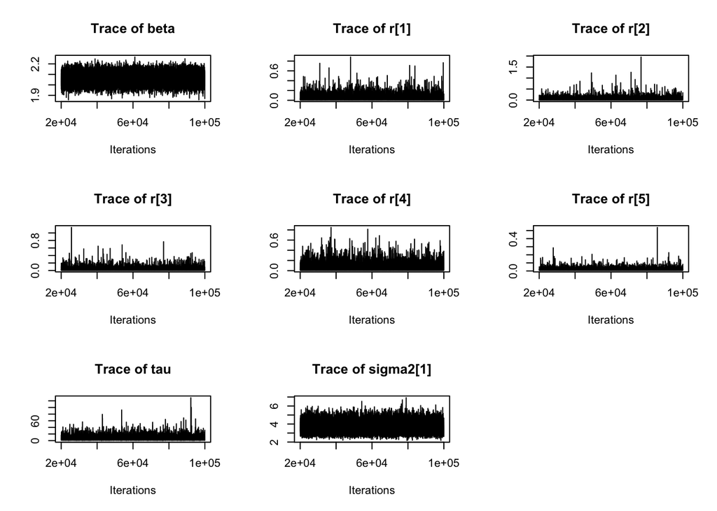

```r
pars <- c("beta", "gamma", paste0("r[", 1:5, "]"), "tau", "sigma2[1]")
available_pars <- pars[pars %in% colnames(samples_hbkmr$samples)]
samples_subset <- samples_hbkmr$samples[, available_pars, drop = FALSE]

coda_obj <- mcmc(samples_subset, start = 20001, end = 1e5)

par(mfrow = c(3, 3))
traceplot(coda_obj)
par(mfrow = c(1, 1))
```

```r
effectiveSize(coda_obj)
```

```
##      beta      r[1]      r[2]      r[3]      r[4]      r[5]       tau sigma2[1]
## 18258.119 10986.031 10926.011 15956.821 13925.258 16016.860  7451.831 16674.346
```

# Comparison of HBKMR and BKMR

```r
names <- c("BKMR", "HBKMR")
waic <- c(samples_bkmr$WAIC$WAIC, samples_hbkmr$WAIC$WAIC)
print(rbind(names, waic = round(waic)))
```

```
##       [,1]   [,2]
## names "BKMR" "HBKMR"
## waic  "782"  "752"
```

In this applied example, the HBKMR model yields an approximately 30-point reduction in WAIC compared to the BKMR model, indicating a notably better fit. To better understand the practical implications of modeling heteroscedasticity, we now compare the two approaches graphically. Although various low-dimensional visualizations of the $h$ function are available, we shall focus on the joint mixture effect plots and predictive intervals to illustrate differences in inference and uncertainty quantification between the models.

## Graphical Summaries

```r
create_plot_data <- function(samps, y, X, Z, W, name){

  beta_indices <- grep("beta", colnames(samps))
  gamma_indices <- grep("gamma", colnames(samps))
  r_indices <- grep("r", colnames(samps))
  tau_indices <- grep("tau", colnames(samps))

  beta <- as.matrix(samps[, beta_indices])
  gamma <- as.matrix(samps[, gamma_indices])
  r <- as.matrix(samps[, r_indices])
  tau <- as.matrix(samps[, tau_indices])

  overall <- makeOverallRiskPlot(
    beta = beta, gamma = gamma, r = r, tau = tau, y = y,
    X = X, Z = Z, W = W, q.fixed = 0.5, q.levels = seq(0.1, 0.9, by = 0.1),
    sel = NULL, method = "exact", nugget = 0
  )

  prediction <- makePredictionInvervalPlot(beta = beta, gamma = gamma,
                                           r = r, tau = tau, y = y, X = X,
                                           Z = Z, W = W, sel = NULL)

  saveRDS(overall, paste0(name, "_overall.rds"))
  saveRDS(prediction, paste0(name, "_prediction.rds"))
}

create_plot_data(samps = samples_bkmr$samples, y = y, X = X, Z = Z,
                         W = as.matrix(rep(1, length(y))), name = "bkmr")

create_plot_data(samps = samples_hbkmr$samples, y = y, X = X, Z = Z,
                         W = as.matrix(cbind(rep(1, length(y)), Z[,3])),
                         name = "hbkmr")
```

### Overall Mixture Effects

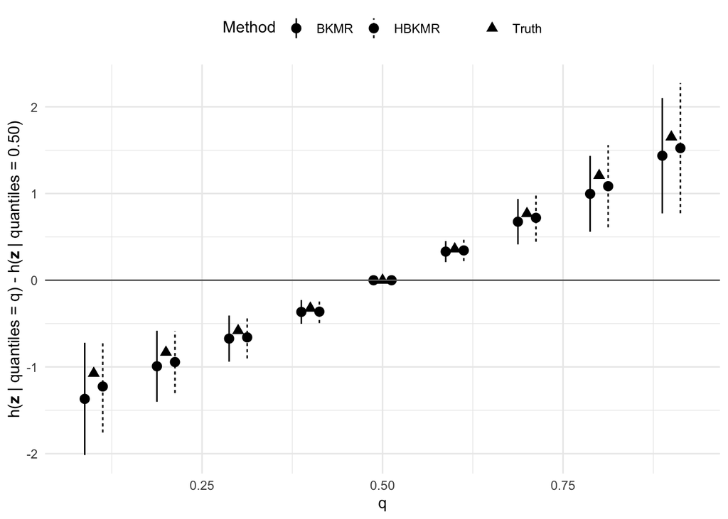

```r
overall_both <- as.data.frame(rbind(overall_hbkmr, overall_bkmr))
overall_both$method <- c(rep('HBKMR', 9), rep('BKMR', 9))

overall_both$lower <- overall_both$est - 1.96*overall_both$sd
overall_both$upper <- overall_both$est + 1.96*overall_both$sd

h_fun <- function(Z) {
  term <- Z[1] + Z[2] + 0.5 * Z[1] * Z[2]
  result <- 4 / (1 + exp(-(1 / 0.3) * (1 / 4) * term))
  return(result)
}

ref <- apply(Z, 2, function(x) quantile(x, 0.5))
new <- apply(Z, 2, function(x) quantile(x, seq(0.1, 0.9, by = 0.1)))
overall_both$truth <- apply(new, 1, h_fun) - h_fun(ref)

ggplot(overall_both, aes(x = q.level)) +
  geom_pointrange(aes(y = est,
                      ymin = est - 1.96 * sd,
                      ymax = est + 1.96 * sd,
                      linetype = method),
                  position = position_dodge(width = 0.05)) +
  geom_point(aes(y = truth, shape = "Truth", color = "Truth"), size = 2.5) +
  geom_hline(yintercept = 0, color = 'gray40') +
  scale_color_manual(name = "", values = c("Truth" = "black")) +
  scale_shape_manual(name = "", values = c("Truth" = 17)) +
  labs(x = "q",
       y = "h(**z** | quantiles = q) - h(**z** | quantiles = 0.50)",
       linetype = "Method") +
  theme_minimal() +
  theme(axis.title.y = element_markdown(),
        axis.title.x = element_markdown(),
        legend.title = element_markdown(),
        plot.title = element_markdown(),
        legend.position = "top")
```

### Prediction Intervals

To assess how well each method adapts to heteroskedasticity, we overlay the true 95% prediction interval width on the figure. In the data-generating process, the conditional variance of the outcome depends on the third mixture component, $z_3$, through the relationship:

$$\sigma^2(z_3) = \exp(1 + 1.2z_3),$$

which implies the conditional standard deviation is:

$$\sigma(z_3) = \sqrt{\exp(1 + 1.2z_3)}.$$

Under a correctly specified normal model, the ideal 95% prediction interval has width:

$$\text{True Width}(z_3) = 2 \times z_{0.975} \times \sigma(z) \approx
3.92 \times \sqrt{\exp(1 + 1.2z_3)},$$
where $z_{(0.975)}$ denotes the 97.5<sup>th</sup> percentile of the standard normal distribution.

This expression defines the benchmark interval width that fully reflects the heteroskedastic structure in the data. In the plot, we display this theoretical width as a **dashed black curve**, allowing direct visual comparison with the empirical interval widths produced by each method.

Methods that closely track this curve demonstrate an appropriate adaptation to the changing variance and are likely to provide more accurate and calibrated predictive uncertainty.

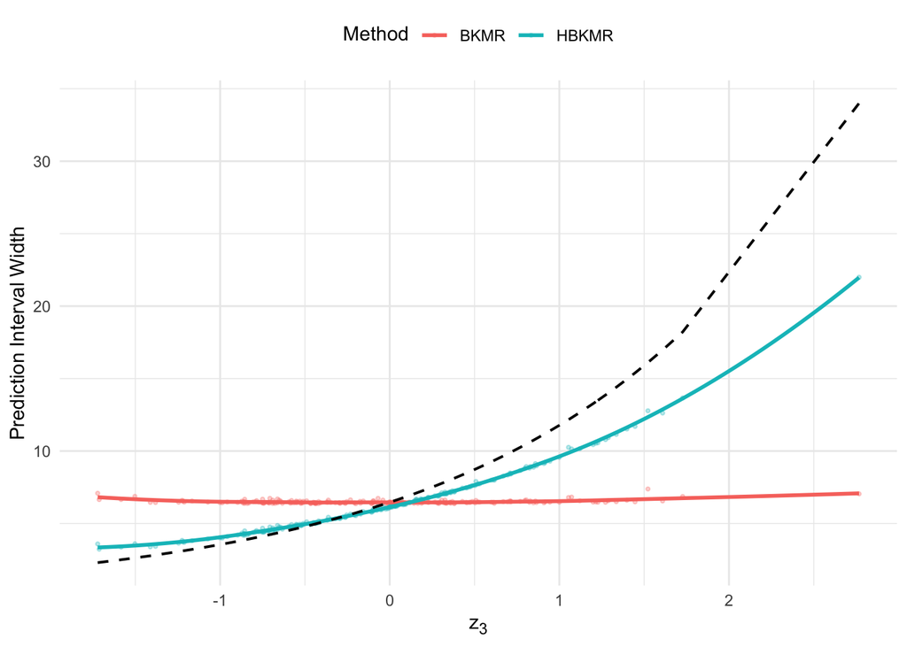

```r
prediction_both <- as.data.frame(rbind(pred_bkmr, pred_hbkmr))

prediction_both$lower <- prediction_both$prediction - 1.96*prediction_both$sd
prediction_both$upper <- prediction_both$prediction + 1.96*prediction_both$sd

prediction_both$method <- c(rep('BKMR', 200), rep('HBKMR', 200))
prediction_both$exposure <- Z[,3]

prediction_both$sigma2 <- exp(1 + 1.2 * prediction_both$exposure)
prediction_both$true_width <- 3.92 * sqrt(prediction_both$sigma2)
prediction_both$width <- prediction_both$upper - prediction_both$lower

ggplot(prediction_both, aes(x = exposure, y = width, color = method)) +
  geom_point(alpha = 0.3, size = 0.7) +
  geom_smooth(method = "loess", span = 0.5, se = FALSE, linewidth = 1) +
  geom_line(aes(y = true_width), color = "black", linetype = "dashed", linewidth = 0.7) +
  labs(
    x = "z<sub>3</sub>",
    y = "Prediction Interval Width",
    color = "Method") +
  theme_minimal() +
  theme(
    axis.title.x = element_markdown(),
    axis.title.y = element_markdown(),
    plot.title = element_markdown(),
    legend.title = element_markdown(),
    legend.position = "top"
  )
```

Bobb, Jennifer F., Birgit Claus Henn, Linda Valeri, and Brent A. Coull. 2018. “Statistical Software for Analyzing the Health Effects of Multiple Concurrent Exposures via Bayesian Kernel Machine Regression.” *Environmental Health* 17 (1): 67. https://doi.org/10.1186/s12940-018-0413-y.